## Data 110.DS1

## March 11, 2021

## Week 10 - NLP Sentiment Analysis

# Assignment Info

```python
import pandas as pd
import numpy as np
from datetime import datetime

import matplotlib.pyplot as plt
import seaborn as sns
```

### Custom Functions

```python
# make lists easier to see
def show_list(list):
    for n in list:
        print(n)

#value_count function
def count_it(df):
    counts = df.value_counts(sort=True)#.reset_index()
    return counts
```

## Import

```python
df = pd.read_csv('Amazon_Consumer_Reviews.csv')

df_vanilla = df.copy('df')
```

```python
df.info()
```

```
<class 'pandas.core.frame.DataFrame'>
RangeIndex: 28332 entries, 0 to 28331
Data columns (total 19 columns):
 #   Column              Non-Null Count  Dtype
---  ------              --------------  -----
 0   id                  28332 non-null  object
 1   dateAdded           28332 non-null  object
 2   dateUpdated         28332 non-null  object
 3   name                28332 non-null  object
 4   asins               28332 non-null  object
 5   brand               28332 non-null  object
 6   categories          28332 non-null  object
 7   primaryCategories   28332 non-null  object
 8   keys                28332 non-null  object
 9   manufacturer        28332 non-null  object
 10  manufacturerNumber  28332 non-null  object
 11  reviews.date        28332 non-null  object
 12  reviews.dateSeen    28332 non-null  object
 13  reviews.numHelpful  16115 non-null  float64
 14  reviews.rating      28332 non-null  int64
 15  reviews.sourceURLs  28332 non-null  object
 16  reviews.text        28332 non-null  object
 17  reviews.title       28332 non-null  object
 18  reviews.username    28332 non-null  object
dtypes: float64(1), int64(1), object(17)
memory usage: 4.1+ MB
```

```python
print(df.shape)
```

```
(28332, 19)
```

19 Different columns/features, only 2 of which are currently numeric.  
28,332 Observations in the df before cleaning.

#### Data Dictionary:

(https://developer.datafiniti.co/docs/product-data-schema)

**id:** The ASIN (Amazon identifier) used for this product.  
**dateAdded:** The date this product was first added to the product database.  
**DateUpdated:** The most recent date this product was updated or seen by our system.  
**name:** The product's name  
**asins:** The ASIN (Amazon identifier) used for this product.  
**brand:** The brand name of this product.  
**categories:** A list of category keywords used for this product across multiple sources.  
**primaryCategories:** A list of standardized categories to which this product belongs.  
**keys:** A list of internal Datafiniti identifiers for this product.  
**manufacturer:** The manufacturer of this product.  
**manfacturerNumber:** The manufacturer or model number of this product.  
**reviews.date:** The date the review was posted.  
**reviews.dateSeen:** The date when the review was seen by Datafiniti.  
**reviews.numHelpful:** The number of people that found this review helpful.  
**reviews.rating:** A 1 to 5 start value for the review.  
**reviews.sourceURLs:** A list of URLs where this review was seen.  
**reviews.text:** The full (or available) text of the review.  
**reviews.title:** The review's title.  
**reviews.username:** The reviewer's username.

Based on the Data Dictionary, it looks like I can already drop a few columns.  
These are:

*dateAdded*  
*DateUpdated*  
*keys*  
*reviews.dateSeen*  
*reviews.sourceURLs*  
*manufacturerNumber*

These columns are used for the aggregators internal organization and don't reflect on the interaction between a consumer and Amazon, or they duplicate data found in other columns.

Other columns that I might consider dropping after further exploration:  
*categories*: full of every category tag for a product, it'll probably be much less useful than 'primaryCategories'.  
*reviews.title*: currently unclear whether or not this contain more/less value than the review body.

Also worth noting when I check for duplicate values, I'm probably not going to see any duplicates if I use each row as a unique key. I might have to consider only a few columns to check for duplicate values.

```python
df = df.drop(columns=['dateAdded','dateUpdated','keys','reviews.dateSeen','reviews.sourceURLs','manufacturerNumber'])
```

```python
print('Original Amount of columns:', len(df_vanilla.columns))
print('Current Columns After cleaning operations:', len(df.columns))
```

```
Original Amount of columns: 19
Current Columns After cleaning operations: 13
```

A quick glance at the df to identify any other cleaning I might want to do before any text work.

```python
df.head(5)
```

|  | id | name | asins | brand | categories | primaryCategories | manufacturer | reviews.date | reviews.numHelpful | reviews.rating | reviews.text | reviews.title | reviews.username |
| --- | --- | --- | --- | --- | --- | --- | --- | --- | --- | --- | --- | --- | --- |
| 0 | AVpgNzjwLJeJML43Kpxn | AmazonBasics AAA Performance Alkaline Batterie... | B00QWO9P0O,B00LH3DMUO | Amazonbasics | AA,AAA,Health,Electronics,Health & Household,C... | Health & Beauty | AmazonBasics | 2017-03-02T00:00:00.000Z | NaN | 3 | I order 3 of them and one of the item is bad q... | ... 3 of them and one of the item is bad quali... | Byger yang |
| 1 | AVpgNzjwLJeJML43Kpxn | AmazonBasics AAA Performance Alkaline Batterie... | B00QWO9P0O,B00LH3DMUO | Amazonbasics | AA,AAA,Health,Electronics,Health & Household,C... | Health & Beauty | AmazonBasics | 2016-08-31T00:00:00.000Z | NaN | 4 | Bulk is always the less expensive way to go fo... | ... always the less expensive way to go for pr... | ByMG |
| 2 | AVpgNzjwLJeJML43Kpxn | AmazonBasics AAA Performance Alkaline Batterie... | B00QWO9P0O,B00LH3DMUO | Amazonbasics | AA,AAA,Health,Electronics,Health & Household,C... | Health & Beauty | AmazonBasics | 2016-12-06T00:00:00.000Z | NaN | 5 | Well they are not Duracell but for the price i... | ... are not Duracell but for the price i am ha... | BySharon Lambert |
| 3 | AVpgNzjwLJeJML43Kpxn | AmazonBasics AAA Performance Alkaline Batterie... | B00QWO9P0O,B00LH3DMUO | Amazonbasics | AA,AAA,Health,Electronics,Health & Household,C... | Health & Beauty | AmazonBasics | 2016-03-28T00:00:00.000Z | NaN | 5 | Seem to work as well as name brand batteries a... | ... as well as name brand batteries at a much ... | Bymark sexson |
| 4 | AVpgNzjwLJeJML43Kpxn | AmazonBasics AAA Performance Alkaline Batterie... | B00QWO9P0O,B00LH3DMUO | Amazonbasics | AA,AAA,Health,Electronics,Health & Household,C... | Health & Beauty | AmazonBasics | 2017-04-22T00:00:00.000Z | NaN | 5 | These batteries are very long lasting the pric... | ... batteries are very long lasting the price ... | Bylinda |

Based on this, I'll also take a quick look at 'categories', 'asins', as well as compare 'reviews.text' to 'reviews.title'

### Missing Values Check

```python
df.isnull().sum()
```

```
id                        0
name                      0
asins                     0
brand                     0
categories                0
primaryCategories         0
manufacturer              0
reviews.date              0
reviews.numHelpful    12217
reviews.rating            0
reviews.text              0
reviews.title             0
reviews.username          0
dtype: int64
```

Null in numHelpful simply indicates that 12+ thousand reviews haven't been marked helpful by other reviewers. There is no faulty data here.

### Duplicate Values Check

Checking for duplicates is a bit tricky as we'll probably see duplicate phrases in reviews like: 'works well', 'ok', etc. This is still data I want to keep; it doesn't provide concrete proof of faulty data. It's simply phrases that many different reviews used.

I'm first checking duplicates using the entire row of columns as a unique key

```python
df.duplicated(keep=False).sum()
```

```
0
```

That didn't turn up any duplicates but I'm going to broaden my criteria a bit to see what I can find.

I'm choosing several columns to open up the search. These are: id, reviews.date, reviews.text, reviews.username.  
If you look back at the data dictionary for a description of each of these, I believe that combining them creates a fairly accurate unique key to identify legitimate faulty data.

```python
df.duplicated(['id','reviews.date','reviews.text','reviews.username'], keep=False).sum()
```

```
87
```

As suspected, this turns up a few duplicates. Here's a peek at those.

```python
dupe_check = df[df.duplicated(['id','reviews.date','reviews.text','reviews.username'], keep=False) == True]
dupe_check = dupe_check[['id','reviews.date','reviews.text','reviews.username']]
dupe_check.head(25)
```

|  | id | reviews.date | reviews.text | reviews.username |
| --- | --- | --- | --- | --- |
| 12088 | AVphC37X1cnluZ0-9mbp | 2015-10-26T00:00:00Z | Can't seem to say enough about this awesome st... | Stephen M. |
| 12089 | AVphC37X1cnluZ0-9mbp | 2015-10-26T00:00:00Z | Can't seem to say enough about this awesome st... | Stephen M. |
| 12090 | AVphC37X1cnluZ0-9mbp | 2015-10-26T00:00:00Z | Can't seem to say enough about this awesome st... | Stephen M. |
| 12093 | AVphC37X1cnluZ0-9mbp | 2015-10-01T00:00:00Z | Every other laptop cooler I have purchased has... | john f |
| 12094 | AVphC37X1cnluZ0-9mbp | 2015-10-01T00:00:00Z | Every other laptop cooler I have purchased has... | john f |
| 12095 | AVphC37X1cnluZ0-9mbp | 2015-10-01T00:00:00Z | Every other laptop cooler I have purchased has... | john f |
| 12123 | AVpe6nyKLJeJML43yOe2 | 2015-06-01T00:00:00Z | BETTER THAN NOTHING, But not as good as the CA... | RaphaelRicardo |
| 12124 | AVpe6nyKLJeJML43yOe2 | 2015-06-01T00:00:00Z | BETTER THAN NOTHING, But not as good as the CA... | RaphaelRicardo |
| 12125 | AVpe6nyKLJeJML43yOe2 | 2015-06-01T00:00:00Z | BETTER THAN NOTHING, But not as good as the CA... | RaphaelRicardo |
| 12126 | AVpe6nyKLJeJML43yOe2 | 2014-11-12T00:00:00Z | Recently, I spent my hard earned money on a 13... | Don Juan |
| 12127 | AVpe6nyKLJeJML43yOe2 | 2014-11-12T00:00:00Z | Recently, I spent my hard earned money on a 13... | Don Juan |
| 12128 | AVpe6nyKLJeJML43yOe2 | 2014-11-12T00:00:00Z | Recently, I spent my hard earned money on a 13... | Don Juan |
| 13754 | AVpfw2hvilAPnD_xh0rH | 2017-01-27T00:00:00.000Z | I like that the tablet has child settings and ... | Juligvkm |
| 13861 | AVpfw2hvilAPnD_xh0rH | 2017-05-14T00:00:00.000Z | Nice and durable good for the kiddos but they ... | Sall |
| 14024 | AVpfw2hvilAPnD_xh0rH | 2017-01-27T00:00:00.000Z | My wife and I wanted our children to still enj... | RCollins912 |
| 14066 | AVpfw2hvilAPnD_xh0rH | 2017-01-27T00:00:00.000Z | My wife and I wanted our children to still enj... | RCollins912 |
| 14252 | AVpfw2hvilAPnD_xh0rH | 2017-01-27T00:00:00.000Z | I like that the tablet has child settings and ... | Juligvkm |
| 14305 | AVpfw2hvilAPnD_xh0rH | 2017-01-23T00:00:00.000Z | A good starter tablet, but very very slow. Don... | FGVargas |
| 14359 | AVpfw2hvilAPnD_xh0rH | 2017-01-23T00:00:00.000Z | A good starter tablet, but very very slow. Don... | FGVargas |
| 14585 | AVpfw2hvilAPnD_xh0rH | 2017-01-06T00:00:00.000Z | Purchased as a Christmas gift for my grandson.... | Jacque |
| 14589 | AVpfw2hvilAPnD_xh0rH | 2016-11-25T00:00:00.000Z | Grand kids love it and it picked up the networ... | 54035723 |
| 14895 | AVpfw2hvilAPnD_xh0rH | 2017-01-12T00:00:00.000Z | Bought 3 of these for my 4 year old, 6 year ol... | MotherOf4 |
| 14898 | AVpfw2hvilAPnD_xh0rH | 2017-01-12T00:00:00.000Z | Bought 3 of these for my 4 year old, 6 year ol... | MotherOf4 |
| 14980 | AVpfw2hvilAPnD_xh0rH | 2016-12-14T00:00:00.000Z | Has been very durable with kids and easy to us... | Mamax3 |
| 15053 | AVpfw2hvilAPnD_xh0rH | 2016-12-30T00:00:00.000Z | This was a gift for my kids. They love them. E... | Jam24 |

I've confirmed the existence of duplicate reviews. Note that I used 'keep=False' because I wanted to see all of the duplicate values for this inspection, but when I drop the values I'm going to use "keep='first'". I don't want to lose any data, just remove the excess duplicates.

```python
print('Verify df observations before duplicate removal', df.shape[0])

df = df.drop_duplicates(subset=['id','reviews.date','reviews.text','reviews.username']) # keep=True is default

print('Verify df observations after duplicate removal', df.shape[0])
```

```
Verify df observations before duplicate removal 28332
Verify df observations after duplicate removal 28286
```

```python
del(dupe_check)
```

### Considering the 'categories' column

I want to find out whether I can get any value out of this column. It looks like there's some interesting content in there, but it's also extremely messy.

```python
print('The number of unique levels in primary categories: ', df['categories'].nunique())
```

```
The number of unique levels in primary categories:  60
```

60 Unique combinations in the column 'categories'. This might be useful, but breaking them out into separate columns could add considerable noise to that dataset. I'm exploring this further to verify that I can't extra any value from this column. Maybe I can find some ordering hierarchy, that would let me extra somee bits of the column for value.

```python
cat_df = df["categories"]
```

```python
print(cat_df.head(5))
print(cat_df.tail(5))
```

```
0    AA,AAA,Health,Electronics,Health & Household,C...
1    AA,AAA,Health,Electronics,Health & Household,C...
2    AA,AAA,Health,Electronics,Health & Household,C...
3    AA,AAA,Health,Electronics,Health & Household,C...
4    AA,AAA,Health,Electronics,Health & Household,C...
Name: categories, dtype: object
28327    Fire Tablets,Tablets,All Tablets,Amazon Tablet...
28328    Fire Tablets,Tablets,All Tablets,Amazon Tablet...
28329    Fire Tablets,Tablets,All Tablets,Amazon Tablet...
28330    Fire Tablets,Tablets,All Tablets,Amazon Tablet...
28331    Fire Tablets,Tablets,All Tablets,Amazon Tablet...
Name: categories, dtype: object
```

An initial glance indicates that there might be some sort of ordering here, but its unclear. I referenced these against the hierarchy found in this webpage: https://developer.datafiniti.co/docs/taxonomy-1-level. While there are also 60 values in that list(signifying some type of relationship), the values in our dataset don't appear to follow the same hierarchy.

I can double check this. Each Category in the df is separated by a commas, so I can just count those and then compare them against datafiniti's taxonomy levels. Anything more than 9 levels(datafiniti's max taxonomy depth) indicates the provided dataset 'categories' doesn't follow any useful ordering, as compared to the levels shown in datafiniti's structure.

```python
cat_df['counts'] = cat_df.str.count(',')
```

```python
cat_df['counts'].describe()
```

```
count    28286.000000
mean        13.183377
std          7.683416
min          3.000000
25%          7.000000
50%         15.000000
75%         17.000000
max         53.000000
Name: categories, dtype: float64
```

As suspected, the provided dataset column 'categories' doesn't contain the same order as the data dictionary, so extracting any extra value from it would likely be a time sink.

```python
print('Original Amount of columns:', len(df_vanilla.columns))
df = df.drop(columns='categories')
print('Current Columns after cleaning activities:', len(df.columns))
```

```
Original Amount of columns: 19
Current Columns after cleaning activities: 12
```

Primary Categories looks to be more useful even though I lose potential granularity provided by 'categories'(assuming I could ever clean it up enough to be useful).

```python
print("The number of unique levels in column 'primary categories':", df["primaryCategories"].nunique())

print('The levels of primary categories are:')
show_list(df["primaryCategories"].unique().tolist())
```

```
The number of unique levels in column 'primary categories': 9
The levels of primary categories are:
Health & Beauty
Electronics
Office Supplies
Animals & Pet Supplies
Home & Garden
Electronics,Furniture
Toys & Games,Electronics
Electronics,Media
Office Supplies,Electronics
```

*Recapping activity so far*

```python
print('df size before intial coersion: ', df_vanilla.shape)
print('df size after intial coersion: ', df.shape)
```

```
df size before intial coersion:  (28332, 19)
df size after intial coersion:  (28286, 12)
```

So far I've trimmed 7 columns off, and a couple dozen rows of duplicates.

```python
del(cat_df)
```

## Adding string length data

```python
# Character Count
df['review_character_count']  = df['reviews.text'].str.len()
```

```python
# word count
df['review_word_count'] = df['reviews.text'].str.split().str.len()
```

## Making Dates more useful

'reviews.date' contains a time string with no value, so I'll remove that and convert the column to a posix format.

```python
df['reviews.date'].head(5)
```

```
0    2017-03-02T00:00:00.000Z
1    2016-08-31T00:00:00.000Z
2    2016-12-06T00:00:00.000Z
3    2016-03-28T00:00:00.000Z
4    2017-04-22T00:00:00.000Z
Name: reviews.date, dtype: object
```

```python
df['date'] = df['reviews.date'].str.split('T').str[0]
df = df.drop(columns='reviews.date')
```

```python
df['date'].head(5)
```

```
0    2017-03-02
1    2016-08-31
2    2016-12-06
3    2016-03-28
4    2017-04-22
Name: date, dtype: object
```

```python
df.date = pd.to_datetime(df.date)
```

```python
df.date.head(5)
```

```
0   2017-03-02
1   2016-08-31
2   2016-12-06
3   2016-03-28
4   2017-04-22
Name: date, dtype: datetime64[ns]
```

```python
# Extra more date info
df['year'] = pd.DatetimeIndex(df['date']).year
df['month'] = pd.DatetimeIndex(df['date']).month
df['day'] = pd.DatetimeIndex(df['date']).day

df['weekday'] = pd.DatetimeIndex(df['date']).weekday
```

### Adding classification target

Create new column 'sent_label'. Reviews with starts 1-3 will be given a value of 0 (negative), while 4-5 will be given a value of 1 (positive).

```python
# glance
print(df['reviews.rating'].value_counts())
```

```
5    19869
4     5637
3     1199
1      965
2      616
Name: reviews.rating, dtype: int64
```

Clearly we're going to have a huge class imbalance using really any critieria. Even if we only chose 5 stars as a positive review, and considered everything else negative, we'd still have to deal with a class imbalance.

```python
condition = [(df['reviews.rating'] <= 3), (df['reviews.rating'] >= 4)]
values = [0,1]

df['sent_label'] = np.select(condition, values)
```

```python
print(df['sent_label'].value_counts())
```

```
1    25506
0     2780
Name: sent_label, dtype: int64
```

Theres the huge class imbalance. Almost a 1 to 10 imbalance shown. We can takes steps to mitigate this using sklearn options in the appropriate classifiers.

```python
del(condition, values)
```

## **Assignment Objective**: Perform Full EDA

## EDA, key statistics and vizualizations

### Character and Word Count

#### Character count

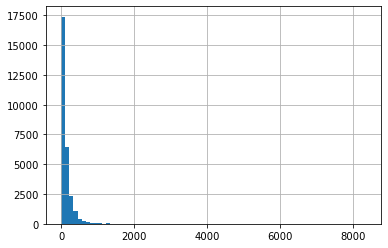

```python
df['review_character_count'].hist(bins=75)
```

df.hist() doesn't show much, so I'm going to use a nicer viz.

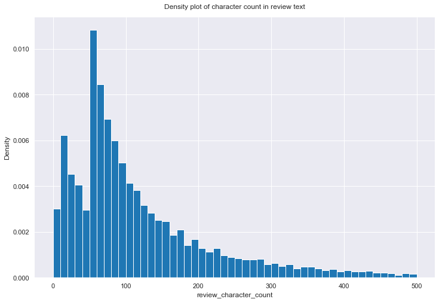

```python
sns.set_theme(style="darkgrid")

plt.figure(figsize=(12, 8))

sns.histplot(data=df, x='review_character_count', binwidth=10, binrange=(0,500), color='tab:blue', alpha=1, stat="density")
plt.title("Density plot of character count in review text", y = 1.02)

sns.despine(left=True)
plt.show()
```

```python
df['review_character_count'].describe()
```

```
count    28286.000000
mean       137.251750
std        199.377542
min          1.000000
25%         54.000000
50%         87.000000
75%        162.000000
max       8351.000000
Name: review_character_count, dtype: float64
```

The average character count is 137, and the 75th Percentile is 162 characters. The max clearly shows an outlier, that we'll explored more in the word counts.

#### Word Count

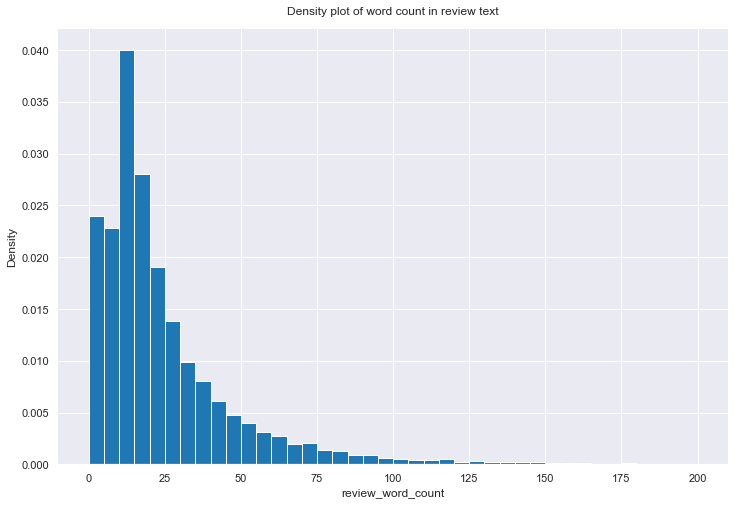

```python
# Word Length
sns.set_theme(style="darkgrid")

plt.figure(figsize=(12, 8))

sns.histplot(data=df, x='review_word_count', binwidth=5, binrange=(0,200), color='tab:blue', alpha=1, stat="density")
plt.title("Density plot of word count in review text", y = 1.02)

sns.despine(left=True)
plt.show()
```

It looks like most people use less than 25 words. I think this makes sense considering Amazon sends out emails asking for feedback on a product, and many people still don't recognize this manner of obtaining reviews, they just think it's amazon asking them a question. We don't have the data, but I'd hazard a guess that most of the shorter word reviews are obtained through this method.

```python
df['review_word_count'].describe()
```

```
count    28286.000000
mean        25.893552
std         36.979516
min          1.000000
25%         10.000000
50%         17.000000
75%         31.000000
max       1539.000000
Name: review_word_count, dtype: float64
```

df.describe() shows us a smiliar pattern, with the 75th percentile still being only 31 words. There appear to be a few people who really like to type, with the max of over 1500 words. Lets checked a few more percentiles.

```python
df['review_word_count'].quantile(q=[0.85,0.9,0.95,0.99])
```

```
0.85     44.0
0.90     55.0
0.95     75.0
0.99    146.0
Name: review_word_count, dtype: float64
```

the 99th percentile is still less than 150 words, which checks against our density plot above.

**A note on outliers:** Typically I'd consider removing some of the data outside of the more extreme percentile ranges, but given that we're doing sentiment analysis, more text means more data to evaluate. Its unlikely that we'll get more information about product sentiment by removing words to be run through our models.

### Brand and Manufacturers

```python
print('\nThere are', df['brand'].nunique(), 'unique brands: ')
show_list(df['brand'].unique())

print('\nThere are', df['manufacturer'].nunique(), 'unique manufacturers: ')
show_list(df["manufacturer"].unique())
```

```
There are 3 unique brands:
Amazonbasics
Amazon
AmazonBasics

There are 4 unique manufacturers:
AmazonBasics
Amazon
Amazon Digital Services
Amazon.com
```

I'm going to remove both of these columns, now that I know all of the products reviewed are Amazon products, and not other brands using the amazon store front. In other words, there's no sentiment value to be found towards a specific brand or manufacturer, this is now excess data.

```python
df = df.drop(columns=['brand','manufacturer'])
```

```python
print('Original DF size: ', df_vanilla.shape)

print('Current DF size, after continued cleaning: ', df.shape)
```

```
Original DF size:  (28332, 19)
Current DF size, after continued cleaning:  (28286, 17)
```

### Product Count and Review Activity

```python
print('The number of unique products is: ', df["id"].nunique())
```

```
The number of unique products is:  65
```

```python
product_viz = df.value_counts(subset=['name'], sort=True).reset_index()

product_viz.head(5)
```

|  | name | 0 |
| --- | --- | --- |
| 0 | AmazonBasics AAA Performance Alkaline Batterie... | 8343 |
| 1 | AmazonBasics AA Performance Alkaline Batteries... | 3728 |
| 2 | Fire HD 8 Tablet with Alexa, 8 HD Display, 16 ... | 2442 |
| 3 | All-New Fire HD 8 Tablet, 8 HD Display, Wi-Fi,... | 2370 |
| 4 | Fire Kids Edition Tablet, 7 Display, Wi-Fi, 16... | 1663 |

Clearly most reviews are centered around a few products. I want to look at this from a different perspective

```python
# Most Reviewed Products
product_viz = df.value_counts(subset=['name'], normalize=True, sort=True).reset_index()

tt10 = "{:.1%}".format(product_viz[0].head(10).sum())
tt20 = "{:.1%}".format(product_viz[0].head(20).sum())
print('The top 10 most reviewed products account for', tt10, 'of all reviews')
print('The top 20 most reviewed products account for', tt20, 'of all reviews')

# Most Reviewed Product
prod = product_viz.iloc[0,0]
perc = "{:.1%}".format(product_viz.iloc[0,1])

print('The most reviewed product is', prod, 'With', perc, 'of all reviews')
```

```
The top 10 most reviewed products account for 85.0% of all reviews
The top 20 most reviewed products account for 96.6% of all reviews
The most reviewed product is AmazonBasics AAA Performance Alkaline Batteries (36 Count) With 29.5% of all reviews
```

```python
# setup
df_pie = product_viz.head(10)

# leftover data
leftovers = round((product_viz[0].tail(55).sum()), 5)
extra_dat = {'name': 'All Other Products', 0:leftovers}

df_pie = df_pie.append(extra_dat, ignore_index=True)
```

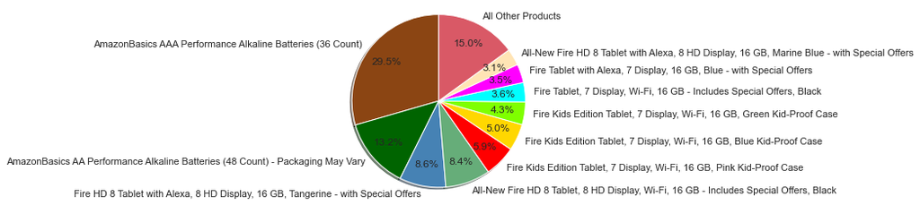

```python
labels = df_pie['name']
sizes = df_pie[0]

colors = ['#8b4513','#006400','#4682b4','#66ad79','#ff0000','#ffd700','#7fff00','#00ffff','#ff00ff','#ffe4b5','#d95966']

fig1, ax1 = plt.subplots()
ax1.pie(sizes, labels=labels, autopct='%1.1f%%',
        shadow=True, startangle=90, normalize=False, pctdistance=0.75, labeldistance=1.1, colors=colors)
ax1.axis('equal')

plt.show()
```

As I presented, in both the textual report and the piechart, a majority of the review activity is focusing on just a few products. I anticipate that this will effect our text analysis on some level. For example, the two top most reviewed products are batteries. We're probably going to see a lot of words centered on that topic.

Related to product types, we have the 'asins' column. I'm going to take a quick look at that to determine if it adds any value that the other product identifiers don't already contain.

```python
print("Unique 'Asins' Values: ", df["asins"].nunique())
```

```
Unique 'Asins' Values:  65
```

```python
show_list(df["asins"].unique())
```

```
B00QWO9P0O,B00LH3DMUO
B00DIHVMEA,B00EZ1ZTV0
B01E6AO69U,B00L9EPT8O
B01J24C0TI
B073SQYXTW
B00ZV9RDKK
B00QWO9P0O,B01IB83NZG,B00MNV8E0C
B00WRDS8H0
B00EEBS9O0,B01CHQHIJK
B01B66989K,B00CD8ADKO,B00LA9H6UM
B00DUGZFWY
B00F5CKWBA,B00KPQCWAU
B0002LCUZK,B010CEC6MI,B01B25NN64
B074MCBG25,B075357QFB
B00QFQRELG
B006GWO7UA
B01L7XWEQQ
B006BGZJJ4
B00Y3QOH5G
B01BH83OOM
B00ZV9PXP2
B00NH144GK,B00LA9H1E8
B00OP6SMCI
B00BGIQS1A
B006LW0W5Y
B0751RGYJV
B00IOY8XWQ
B010RLCH2U
B01GAGYVU2
B0752151W6
B018SZT3BK,B01AHB9CN2
B018Y226XO
B01AHB9CYG
B01ACEKAJY
B00REQKWGA
B00IOYAM4I
B01IO618J8
B018Y22BI4
B01AHBBG04
B01AHBDCKQ
```

[output cut: 10 more lines]

```
B018Y224PY
B00VKTZFB4
B018Y225IA
B00ZS0G0PG
B06XD5YCKX
B018Y22C2Y
B01AHB9C1E
B018Y23MNM
B017JG41PC
B00XNQECFM
B00UH4D8G2
B06XCWLL12
B005OOKNP4
B001NIZB5M
B018T075DC
```

It looks like Asins is just another internal method of identifying different products. I don't think it adds any value to our assignment goal, so I'm removing it. I plugged some of these values into google, and the first set of characters leads to the product page, while any other sets after that point to review pages. This won't add any value to our goals in this dataset.

```python
df = df.drop(columns=['asins'])
```

```python
print('Original DF size: ', df_vanilla.shape)

print('Current DF size: ', df.shape)
```

```
Original DF size:  (28332, 19)
Current DF size:  (28286, 16)
```

```python
del(product_viz, tt10, tt20, prod, perc, df_pie, leftovers, extra_dat, labels, sizes, colors, fig1, ax1)
```

### Most Active Reviewers

```python
# Create Reviewers DF
reviewers = df.value_counts(subset=['reviews.username'], sort=True).reset_index()
reviewers_perc = df.value_counts(subset=['reviews.username'], normalize=True, sort=True).reset_index()
```

```python
print('there are', reviewers_perc.shape[0] , 'Unique Reviewers in the dataset')
```

```
there are 16269 Unique Reviewers in the dataset
```

```python
print('The most active reviewer is', reviewers_perc.iloc[0,0], 'with', "{:.1%}".format(reviewers_perc.iloc[0,1]), 'of all reviews, a total of', reviewers.iloc[0,1], 'reviews' )
```

```
The most active reviewer is ByAmazon Customer with 3.1% of all reviews, a total of 889 reviews
```

```python
b = df.groupby(['reviews.username',])['review_word_count'].agg(lambda x: x.unique().mean())
print('Top ten reviewers by average word count\n', b.sort_values(ascending=False).head(10))
```

```
Top ten reviewers by average word count
 reviews.username
ByMykers              888.0
ljbinion              709.0
Sluggo2013            669.0
Jojoleb jojoleb       536.0
Happytekki            503.0
Zookeeper             469.0
Want300               466.0
AlphaKryptonyte       426.0
ByAmanda R. LaRosa    423.0
ByManny               422.0
Name: review_word_count, dtype: float64
```

```python
del(reviewers, reviewers_perc, b)
```

### Date Exploration

```python
count_it(df['year'])
```

```
2017    13316
2016    11696
2015     2381
2018      761
2014       99
2013       13
2019        9
2012        5
2009        3
2011        3
Name: year, dtype: int64
```

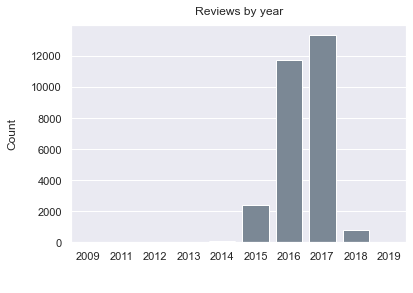

```python
sns.countplot(x='year', data=df, color='lightslategrey')
plt.xlabel(" ", labelpad=14)
plt.ylabel("Count", labelpad=14)
plt.title("Reviews by year", y = 1.02)
plt.show()
```

While the dataset contains observations from a ten year period, the large majority of the observations take place in 2016 and 2017. While this may have something to do with the products included in the dataset, it could also be a function of the how the data aggregator collected these observations.

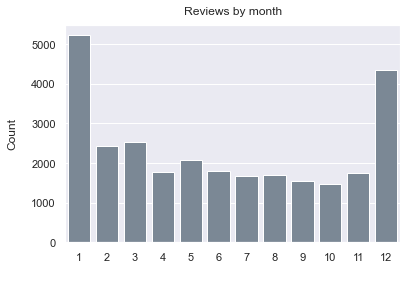

```python
sns.countplot(x='month', data=df, color='lightslategrey')
plt.xlabel(" ", labelpad=14)
plt.ylabel("Count", labelpad=14)
plt.title("Reviews by month", y = 1.02)
plt.show()
```

Interesting to note that most reviews took place in January or December, while all other months remained relative equal in activity. I'd bet this is due to christmas shopping, and people reviewing christmas presents.

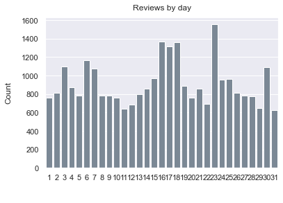

```python
sns.countplot(x='day', data=df, color='lightslategrey')
plt.xlabel(" ", labelpad=14)
plt.ylabel("Count", labelpad=14)
plt.title("Reviews by day", y = 1.02)
plt.show()
```

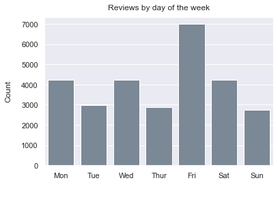

```python
sns.countplot(x='weekday', data=df, color='lightslategrey')
plt.xlabel(" ", labelpad=14)
plt.ylabel("Count", labelpad=14)
plt.title("Reviews by day of the week", y = 1.02)
plt.xticks(np.arange(7), ('Mon', 'Tue', 'Wed', 'Thur', 'Fri', 'Sat', 'Sun'))
plt.show()
```

Interesting that Friday counts more review activity, but aside from being the day before the weekend, I don't see anything strange here.

### Comparing contents of review.title and review.text

I want to see whether reviews.title and reviews.text contain different information, and if I can drop one of them without losing data.

```python
df['reviews.title'].iloc[5,]
```

```
"... batteries for Christmas and the AmazonBasics Cell have been good. I haven't noticed a difference between the brand ..."
```

```python
df['reviews.text'].iloc[5,]
```

```
"Bought a lot of batteries for Christmas and the AmazonBasics Cell have been good. I haven't noticed a difference between the brand name batteries and the Amazon Basic brand. Just a lot easier to purchase and have arrive at the house and have on hand. Will buy again."
```

This first look indicates that the title is just an exert of the review text. I'll look at a few more examples to confirm.

```python
list(df['reviews.title'].iloc[25:30,])
```

```
['... not used yet but a battery is a battery good price',
 '... of batteries that were not as strong or were pretty weak but out of a box of 48 batteries',
 "... ordered these a few times cause we've been so happy with product",
 '... THEM BUT HOPEFULLY ALL OF THEM WILL REMAIN IN GOOD ORDER FOR A REASONABLE AMOUNT OF TIME MEANING A ...',
 '... there to fit the light when they arrived and nice company they were not the batteries we needed it ...']
```

```python
list(df['reviews.text'].iloc[25:30,])
```

```
['have not used yet but a battery is a battery good price',
 'These Amazon batteries did the job although I gave 4star only because I had a few I would say a hand full of batteries that were not as strong or were pretty weak but out of a box of 48 batteries, I will definitely buy again for this priceIm pretty well satisfied.Thank you!',
 "We've ordered these a few times cause we've been so happy with product. These are good quality. We are also happy with price. I would recommend these.",
 'HAVE NOT HAD CHANCE TO USE ALL OF THEM BUT HOPEFULLY ALL OF THEM WILL REMAIN IN GOOD ORDER FOR A REASONABLE AMOUNT OF TIME MEANING A FEW YEARS OUT.',
 'these were under a light we thought they were there to fit the light when they arrived and nice company they were not the batteries we needed it should have been aa but that is ok,it was our fault not knowing this. thanks..']
```

After checking these samples, I feel confident about removing 'reviews.title'. It looks like the title column is always just an exert of the review body.

```python
df = df.drop(columns=['reviews.title'])
```

```python
print('df size before initial coersion: ', df_vanilla.shape)

print('df size after further cleaning: ', df.shape)
```

```
df size before initial coersion:  (28332, 19)
df size after further cleaning:  (28286, 15)
```

## **Assignment Objective**: Text Cleaning and Analysis

```python
# Create Dataframe for Sklearn usage/cleaning
# df_ml = df[['reviews.text','sent_label']]
```

### Lowercase

```python
# Before Sample
df_vanilla['reviews.text'].iloc[27,]
```

```
"We've ordered these a few times cause we've been so happy with product. These are good quality. We are also happy with price. I would recommend these."
```

```python
df['reviews.text'] = df['reviews.text'].apply(lambda x:x.lower())
```

```python
# After Sample
df['reviews.text'].iloc[27,]
```

```
"we've ordered these a few times cause we've been so happy with product. these are good quality. we are also happy with price. i would recommend these."
```

### Remove Numbers

```python
##  Before Sample
df_vanilla['reviews.text'].iloc[26,]
```

```
'These Amazon batteries did the job although I gave 4star only because I had a few I would say a hand full of batteries that were not as strong or were pretty weak but out of a box of 48 batteries, I will definitely buy again for this priceIm pretty well satisfied.Thank you!'
```

```python
df['reviews.text'] = df['reviews.text'].str.replace('\d+', '', regex=True)
```

```python
##  Before Sample
df['reviews.text'].iloc[26,]
```

```
'these amazon batteries did the job although i gave star only because i had a few i would say a hand full of batteries that were not as strong or were pretty weak but out of a box of  batteries, i will definitely buy again for this priceim pretty well satisfied.thank you!'
```

### Remove Punctuation

```python
##  Before Sample
show_list(list(df_vanilla['reviews.text'].iloc[20:25,]))
```

```
This my second order and they seem to work as good as name brand and ship to my door.
This was my second purchase of amazon batteries and they work great. Just as good or even better than name brand batteries and half the price. This will be the only way I purchase batteries from now on!
They last as long as Duracell batteries in my Xbox one controllers and none of them exploded like some of the reviews said.
they seemed to not last as long as other name brand names disappointed!
These do not last long at all very cheap batteries no happy
```

```python
df['reviews.text'] = df['reviews.text'].str.replace('[^\w\s]','',regex=True)
```

```python
##  Before Sample
show_list(list(df['reviews.text'].iloc[20:25,]))
```

```
this my second order and they seem to work as good as name brand and ship to my door
this was my second purchase of amazon batteries and they work great just as good or even better than name brand batteries and half the price this will be the only way i purchase batteries from now on
they last as long as duracell batteries in my xbox one controllers and none of them exploded like some of the reviews said
they seemed to not last as long as other name brand names disappointed
these do not last long at all very cheap batteries no happy
```

### Remove WhiteSpaces

```python
df['reviews.text'] = df['reviews.text'].str.strip()
```

### Tokenize

```python
import nltk
from nltk.corpus import stopwords
from nltk import word_tokenize
```

```python
df['reviews.text'] = df['reviews.text'].fillna('') #required for tokenize to function, inspite of earlier NA checking returning nothing in this column.
```

```python
df['reviews_tokens'] = df['reviews.text'].apply(word_tokenize)

print('Before Tokenizing\n')
show_list(list(df_vanilla['reviews.text'].iloc[20:25,]))
```

```
Before Tokenizing

This my second order and they seem to work as good as name brand and ship to my door.
This was my second purchase of amazon batteries and they work great. Just as good or even better than name brand batteries and half the price. This will be the only way I purchase batteries from now on!
They last as long as Duracell batteries in my Xbox one controllers and none of them exploded like some of the reviews said.
they seemed to not last as long as other name brand names disappointed!
These do not last long at all very cheap batteries no happy
```

```python
print('After Tokenizing\n')
show_list(list(df['reviews_tokens'].iloc[20:25,]))
```

```
After Tokenizing

['this', 'my', 'second', 'order', 'and', 'they', 'seem', 'to', 'work', 'as', 'good', 'as', 'name', 'brand', 'and', 'ship', 'to', 'my', 'door']
['this', 'was', 'my', 'second', 'purchase', 'of', 'amazon', 'batteries', 'and', 'they', 'work', 'great', 'just', 'as', 'good', 'or', 'even', 'better', 'than', 'name', 'brand', 'batteries', 'and', 'half', 'the', 'price', 'this', 'will', 'be', 'the', 'only', 'way', 'i', 'purchase', 'batteries', 'from'…
['they', 'last', 'as', 'long', 'as', 'duracell', 'batteries', 'in', 'my', 'xbox', 'one', 'controllers', 'and', 'none', 'of', 'them', 'exploded', 'like', 'some', 'of', 'the', 'reviews', 'said']
['they', 'seemed', 'to', 'not', 'last', 'as', 'long', 'as', 'other', 'name', 'brand', 'names', 'disappointed']
['these', 'do', 'not', 'last', 'long', 'at', 'all', 'very', 'cheap', 'batteries', 'no', 'happy']
```

### Removing Stop Words

```python
stop = set(stopwords.words('english'))

print('Before Stop Word Removal\n')
show_list(list(df['reviews_tokens'].iloc[20:25,]))
df['reviews_tokens'] = df['reviews_tokens'].apply(lambda x: [item for item in x if item not in stop])

print('\nAfter Stop Word Removal\n')
show_list(list(df['reviews_tokens'].iloc[20:25,]))
```

```
Before Stop Word Removal

['this', 'my', 'second', 'order', 'and', 'they', 'seem', 'to', 'work', 'as', 'good', 'as', 'name', 'brand', 'and', 'ship', 'to', 'my', 'door']
['this', 'was', 'my', 'second', 'purchase', 'of', 'amazon', 'batteries', 'and', 'they', 'work', 'great', 'just', 'as', 'good', 'or', 'even', 'better', 'than', 'name', 'brand', 'batteries', 'and', 'half', 'the', 'price', 'this', 'will', 'be', 'the', 'only', 'way', 'i', 'purchase', 'batteries', 'from'…
['they', 'last', 'as', 'long', 'as', 'duracell', 'batteries', 'in', 'my', 'xbox', 'one', 'controllers', 'and', 'none', 'of', 'them', 'exploded', 'like', 'some', 'of', 'the', 'reviews', 'said']
['they', 'seemed', 'to', 'not', 'last', 'as', 'long', 'as', 'other', 'name', 'brand', 'names', 'disappointed']
['these', 'do', 'not', 'last', 'long', 'at', 'all', 'very', 'cheap', 'batteries', 'no', 'happy']

After Stop Word Removal

['second', 'order', 'seem', 'work', 'good', 'name', 'brand', 'ship', 'door']
['second', 'purchase', 'amazon', 'batteries', 'work', 'great', 'good', 'even', 'better', 'name', 'brand', 'batteries', 'half', 'price', 'way', 'purchase', 'batteries']
['last', 'long', 'duracell', 'batteries', 'xbox', 'one', 'controllers', 'none', 'exploded', 'like', 'reviews', 'said']
['seemed', 'last', 'long', 'name', 'brand', 'names', 'disappointed']
['last', 'long', 'cheap', 'batteries', 'happy']
```

### Lemmatize

```python
def lemmatize_text(text):
    lemmatizer = nltk.WordNetLemmatizer()
    return [lemmatizer.lemmatize(w) for w in text]
```

```python
df['review_lems'] = df['reviews_tokens'].apply(lemmatize_text)
```

```python
print('Before Lemmatizing\n')
show_list(list(df['reviews_tokens'].iloc[20:25,]))

print('\nAfter Lemmatizing\n')
show_list(list(df['review_lems'].iloc[20:25,]))
```

```
Before Lemmatizing

['second', 'order', 'seem', 'work', 'good', 'name', 'brand', 'ship', 'door']
['second', 'purchase', 'amazon', 'batteries', 'work', 'great', 'good', 'even', 'better', 'name', 'brand', 'batteries', 'half', 'price', 'way', 'purchase', 'batteries']
['last', 'long', 'duracell', 'batteries', 'xbox', 'one', 'controllers', 'none', 'exploded', 'like', 'reviews', 'said']
['seemed', 'last', 'long', 'name', 'brand', 'names', 'disappointed']
['last', 'long', 'cheap', 'batteries', 'happy']

After Lemmatizing

['second', 'order', 'seem', 'work', 'good', 'name', 'brand', 'ship', 'door']
['second', 'purchase', 'amazon', 'battery', 'work', 'great', 'good', 'even', 'better', 'name', 'brand', 'battery', 'half', 'price', 'way', 'purchase', 'battery']
['last', 'long', 'duracell', 'battery', 'xbox', 'one', 'controller', 'none', 'exploded', 'like', 'review', 'said']
['seemed', 'last', 'long', 'name', 'brand', 'name', 'disappointed']
['last', 'long', 'cheap', 'battery', 'happy']
```

### Most Common Words

```python
word_count = []
for row in df['review_lems']:
    word_count += row

word_freq = pd.Series(word_count).value_counts()
word_freq= word_freq.to_frame().reset_index()
word_freq = word_freq.head(25).rename(columns={'index':'word', 0:'count'}) # Top 25
```

[figure not shown]

```python
sns.set_theme(style="darkgrid")
plt.figure(figsize=(16, 8))

plt.subplot(1, 2, 1)
sns.barplot(data=word_freq, y='word' , x='count', color='tab:blue')
plt.title("Most Positive Words Identified by Vader", y = 1.02)
sns.despine(left=True)

sns.despine(left=True)
plt.show()
```

I wouldn't consider this to be very valuable, since we're only dealing with 65 products. The fact that 'battery' is one of the most frequent word points back to the most reviewed product, not that fact that every product reviewed had lots of people talking about it's batteries. We can also see some of the class imbalance spilling over here, many of the top words have positive sentiments.

## **Assignment Objective**: Modeling. Create ML and Lexicon Based Models

```python
from sklearn.model_selection import train_test_split
from sklearn import model_selection


from sklearn.pipeline import Pipeline
from sklearn.pipeline import make_pipeline

#Text Tools
from sklearn.feature_extraction.text import TfidfVectorizer, CountVectorizer
from sklearn.feature_selection import SelectKBest, mutual_info_classif
from nltk.tokenize import RegexpTokenizer
from sklearn.preprocessing import StandardScaler

# Scoring tools
from sklearn import metrics
from sklearn.model_selection import cross_val_score, GridSearchCV
from sklearn.metrics import confusion_matrix, plot_confusion_matrix, accuracy_score, classification_report, f1_score
from sklearn.datasets import make_classification
from sklearn.dummy import DummyClassifier

# Models
from sklearn.linear_model import LogisticRegression
from sklearn.naive_bayes import MultinomialNB, ComplementNB
from sklearn.svm import LinearSVC
```

### **Assignment Objective**: Create 3 models using pipelines

I'll be using the following sklearn guide to choose my classifier: https://scikit-learn.org/stable/tutorial/machine_learning_map/index.html

I'm using LogisticRegression for a general baseline.

I'm using LinearSVC according to the sklearn flowchart. I chose MultiNomialNB just to pick a model in the NaiveBayes family, in accordance with the linked flowchart.

I chose ComplementNB because the documentation specifically mentions that it's well suited for imbalanced data sets(#Assignment Objective)

## Building Initial Pipeline

```python
x = df['reviews.text']
y = df['sent_label']

x_train, x_test, y_train, y_test = train_test_split(x, y, test_size=0.2, random_state=79, shuffle=True)
```

```python
text_processing = Pipeline([('tfid_vectorizer', TfidfVectorizer(lowercase=True, stop_words='english', strip_accents='ascii')), #text cleaning also takes place here
                          ('classifier', LogisticRegression())]) #placeholder
```

## Comparing Models

#### **Assignment Objective**: consider the case of imbalanced data

```python
# Models to Compare
model_search = [
                {'classifier': [LogisticRegression(class_weight='balanced')]}, #Assignment Objective
                {'classifier': [LinearSVC(class_weight='balanced')]}, #Assignment Objective
                {'classifier': [MultinomialNB()]},
                {'classifier': [ComplementNB()]}
                                                ]
```

#### **Assignment Objective**: Perform Cross Validation using stratefied KFold

```python
kfold = model_selection.StratifiedKFold(n_splits=10, random_state=79, shuffle=True) #Assignment Objective

model_compare = GridSearchCV(text_processing, model_search, cv=kfold, n_jobs=-1, return_train_score=False)

model_compare = model_compare.fit(x_train, y_train)
```

```python
results = pd.DataFrame(model_compare.cv_results_,columns=['param_classifier', 'mean_test_score'])
results['mean_test_score'] = round(results['mean_test_score'], 3)
results = results.sort_values(by='mean_test_score', ascending=False)
```

```python
print(results)
```

```
                              param_classifier  mean_test_score
3                               ComplementNB()            0.917
1           LinearSVC(class_weight='balanced')            0.914
2                              MultinomialNB()            0.907
0  LogisticRegression(class_weight='balanced')            0.891
```

```python
print(model_compare.best_estimator_)
print(round(model_compare.best_score_, 3))
```

```
Pipeline(steps=[('tfid_vectorizer',
                 TfidfVectorizer(stop_words='english', strip_accents='ascii')),
                ('classifier', ComplementNB())])
0.917
```

After pulling the info out of cv_results, and then cross verifying against built in functions, I've determined that ComplementNB performs the best out of the 4 models tested. Given that the documentation for ComplementNB says it's particularly suited for imbalanced data sets, I think I can move forward without any fear of accidental success from this model. In the spirit of being more communicative about my model selection: I'm basically just following the sklearn flowchart, and then choosing models in order of scoring. An alternate method would be to gridsearch every classifier type model in the sklearn library, but in this case I'm going to defer to guide they've already provided.

I'm going to try a quick hyperparameter tune, since ComplementNB doesn't have a ton of complexity in that aspect. I won't be performning hyperparamenter tuning for the remaining models in the interest of time.

### ComplementNB

```python
# HyperParameter GridSearch
search_space = [
                {'classifier': [ComplementNB()],
                 'classifier__alpha': [0.05, 0.1, 0.15, 0.2, 0.25, 0.3, 0.35, 0.4, 0.45, 0.5, 0.55, 0.6, 1.0],
                 'classifier__alpha': np.arange(0.05, 0.5, 0.01).tolist(),
                 'classifier__norm': ['True', 'False']
                    }]

clf = GridSearchCV(text_processing, search_space, cv=kfold, verbose=0, n_jobs=-1, scoring='accuracy', return_train_score=False)

clf = clf.fit(x_train, y_train)
```

```python
print(clf.best_params_)
print(round(clf.best_score_, 5))
```

```
{'classifier': ComplementNB(alpha=0.14, norm='True'), 'classifier__alpha': 0.14, 'classifier__norm': 'True'}
0.93084
```

```
              precision    recall  f1-score   support

           0       0.71      0.53      0.60       543
           1       0.95      0.98      0.96      5115

    accuracy                           0.93      5658
   macro avg       0.83      0.75      0.78      5658
weighted avg       0.93      0.93      0.93      5658
```

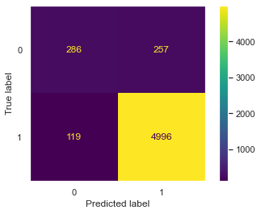

```python
# Looking Closer at ComplementNB
CNB_pipe = Pipeline([('tfid_vectorizer', TfidfVectorizer(lowercase=True, stop_words='english')),
                     ('classifier', ComplementNB(alpha=0.16, norm=True))])

CNB_model = CNB_pipe.fit(x_train, y_train)

y_predict_cnb = CNB_model.predict(x_test)

print(classification_report(y_test, y_predict_cnb))

plot_confusion_matrix(CNB_model, x_test, y_test)
plt.grid(None)
plt.show()
```

```python
# Scores to compare against Lexicons
ml_accuracy = round(accuracy_score(y_predict_cnb, y_test), 3)
ml_f1 = round(f1_score(y_predict_cnb, y_test), 3)
```

**Thoughts**  
From Sklearn documentation:  
"The F1 score can be interpreted as a weighted average of the precision and recall, where an F1 score reaches its best value at 1 and worst score at 0. The relative contribution of precision and recall to the F1 score are equal."

"weighted:  
Calculate metrics for each label, and find their average weighted by support (the number of true instances for each label). This alters ‘macro’ to account for label imbalance; it can result in an F-score that is not between precision and recall."

Given this information, I belive that considering model performance by looking at weighted F1 score is a good choice. A Weighed F1 of 93% isn't horrible considering we've only taken basic steps to clean the data. We can clearly see the effects of the class imbalance, even thought we've taken steps to mitigate this when possible. The Model has high scores across the board in identifying our majority class(positive ratings), but shows less success when identifying the minority class(negative ratings). In addition the overall accuracy in identifying the correct sentiment was also pretty high, and ended up performing better than Vader.

*We'll continue, and look at LinearSVC and MultinomialNB models since they were runners up in our first gridsearch for model comparison.*

### LinearSVC

```
              precision    recall  f1-score   support

           0       0.54      0.81      0.65       543
           1       0.98      0.93      0.95      5115

    accuracy                           0.92      5658
   macro avg       0.76      0.87      0.80      5658
weighted avg       0.94      0.92      0.92      5658
```

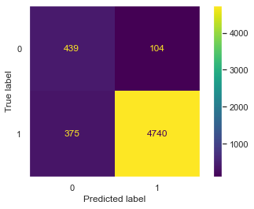

```python
# Looking Closer at ComplementNB
LSV_pipe = Pipeline([('tfid_vectorizer', TfidfVectorizer(lowercase=True, stop_words='english')),
                     ('classifier', LinearSVC(class_weight='balanced'))])

LSV_model = LSV_pipe.fit(x_train, y_train)

y_predict = LSV_model.predict(x_test)

print(classification_report(y_test, y_predict))

plot_confusion_matrix(LSV_model, x_test, y_test)
plt.grid(None)
plt.show()
```

LinearSVC has consistently performed well in our past assignments for binary classification targets, so I'm not particularly suprised that it's performed well here too. One thing I found particularly interesting was it's dramatic improvent in recall score for 0, compared to the complement model. Given that we are interesting in identifying positive and negative sentiment, this model performs pretty well in identifying both. Because identifying both classes is equally import for sentiment analysis, This model appears to be perform best so far.  
I think it's also worth nothing that this model has the highest macro F1 score, a metric that gives a well rounded view of the model performance in precision and recall.

### MultiNomialNB

```
              precision    recall  f1-score   support

           0       0.94      0.09      0.16       543
           1       0.91      1.00      0.95      5115

    accuracy                           0.91      5658
   macro avg       0.93      0.54      0.56      5658
weighted avg       0.91      0.91      0.88      5658
```

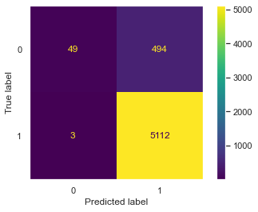

```python
# Looking Closer at ComplementNB
MNB_pipe = Pipeline([('tfid_vectorizer', TfidfVectorizer(lowercase=True, stop_words='english')),
                     ('classifier', MultinomialNB())])

MNB_model = MNB_pipe.fit(x_train, y_train)

y_predict = MNB_model.predict(x_test)

print(classification_report(y_test, y_predict))

plot_confusion_matrix(MNB_model, x_test, y_test)
plt.grid(None)
plt.show()
```

It looks like this model was a victim of the class imbalance, and unfortunately it doesn't provide a class balancing argument within itself. It performed admirably in identifying the class majority, but fell well short of any meaninful identication of the minority class, negative reviews.

## **Assignment Objective**:

Lexicon Exercise. Use any lexicon, and assess performance using appropriate performance metrics. Compare between the two approaches(ML/Vader)

## Vader

```python
from vaderSentiment.vaderSentiment import SentimentIntensityAnalyzer
```

```python
sid = SentimentIntensityAnalyzer()
```

```python
df['vader_score'] = df['reviews.text'].apply(lambda review: sid.polarity_scores(review))
```

```python
df['vader_score'].head(5)
```

```
0    {'neg': 0.169, 'neu': 0.831, 'pos': 0.0, 'comp...
1    {'neg': 0.0, 'neu': 0.828, 'pos': 0.172, 'comp...
2    {'neg': 0.0, 'neu': 0.602, 'pos': 0.398, 'comp...
3    {'neg': 0.0, 'neu': 0.706, 'pos': 0.294, 'comp...
4    {'neg': 0.0, 'neu': 0.687, 'pos': 0.313, 'comp...
Name: vader_score, dtype: object
```

```python
df3 = df[['reviews.text']]
df3 = df.join(pd.DataFrame(df.pop('vader_score').values.tolist()))
```

```python
df3 = df3[['name','review_lems','neg','neu','pos','compound','sent_label']]
```

```python
df3.head(5)
```

|  | name | review_lems | neg | neu | pos | compound | sent_label |
| --- | --- | --- | --- | --- | --- | --- | --- |
| 0 | AmazonBasics AAA Performance Alkaline Batterie... | [order, one, item, bad, quality, missing, back... | 0.169 | 0.831 | 0.000 | -0.6908 | 0 |
| 1 | AmazonBasics AAA Performance Alkaline Batterie... | [bulk, always, le, expensive, way, go, product... | 0.000 | 0.828 | 0.172 | 0.3612 | 1 |
| 2 | AmazonBasics AAA Performance Alkaline Batterie... | [well, duracell, price, happy] | 0.000 | 0.602 | 0.398 | 0.7650 | 1 |
| 3 | AmazonBasics AAA Performance Alkaline Batterie... | [seem, work, well, name, brand, battery, much,... | 0.000 | 0.706 | 0.294 | 0.6124 | 1 |
| 4 | AmazonBasics AAA Performance Alkaline Batterie... | [battery, long, lasting, price, great] | 0.000 | 0.687 | 0.313 | 0.6249 | 1 |

Adding labels based on compound scores will help compare to the ML techniques.

According to Vader Documentation(https://github.com/cjhutto/vaderSentiment), the following is true:  
*positive sentiment: compound score >= 0.05*  
*neutral sentiment: (compound score > -0.05) and (compound score < 0.05)*  
*negative sentiment: compound score <= -0.05*  
The range of sentiment value is from -1.0 to 1.0, most negative to most positive.

Since we only labled positive and negative in our original df, I'm going to summarize this into compound > 0 as positive, and compound <= 0 as negative. This gives us access to better scoring methods against the sklearn models.

```python
condition = [(df3['compound'] > 0 ), (df3['compound'] <=  0)]
values = [1, 0]

df3['vader_label'] = np.select(condition, values)
```

### **Assignment Objective:** Evaluating Vader against ComplementNB

```python
# create comparison column for vader predicted values, vs known values from initial labeling
comparison_column = np.where(df3["sent_label"] == df3["vader_label"], True, False)
comparison_column = pd.DataFrame(comparison_column,columns=['score'])

# pull numeric values
obs_count = comparison_column.shape[0]
val_count = comparison_column.value_counts()
val_counts = val_count.iloc[0,]
right = "{:.1%}".format(val_counts/obs_count)

print('The total number of observations was', obs_count, 'and the number that Vader correctly identified was', val_counts)
print('Vader was correct', right, 'of the time')
```

```
The total number of observations was 28286 and the number that Vader correctly identified was 23640
Vader was correct 83.6% of the time
```

```python
# Using sklearn tools
known_sent = df['sent_label'].values.flatten()
vader_sent = df3['vader_label'].values.flatten()

vader_accuracy = round(accuracy_score(known_sent, vader_sent), 3)

vader_f1 = round(f1_score(known_sent, vader_sent), 3)
vader_f1 = "{:.1%}".format(vader_f1)
ml_f1 = "{:.1%}".format(ml_f1)

vader_accuracy = "{:.1%}".format(vader_accuracy)
ml_accuracy = "{:.1%}".format(ml_accuracy)
```

```python
print('Vader Accuracy is:', vader_accuracy, 'compared to ComplemmentNBs accuracy of:', ml_accuracy )
print('Vader F1-score is:', vader_f1, 'compared to ComplemmentNBs F1-score of:', ml_f1 )
```

```
Vader Accuracy is: 83.6% compared to ComplemmentNBs accuracy of: 93.4%
Vader F1-score is: 90.6% compared to ComplemmentNBs F1-score of: 96.4%
```

**Thoughts:**  
Given how much less time it takes to get sentiment values out of vader(once I figured it out anyway), I'm surprised at it's scoring comparing to the sklearn ML classifiers.

In terms of real world application, I think Vader would be a great way to get a 'quick and dirty' idea of sentiment value in text, which could then be further refining in an sklearn classifier. Personally I'm really enjoing the sklearn package, so I would continue to use that. That being said, I'm aware that Vader has some great applications for use on social media, including emoji sentiment, so I think the strategic objective would dictate which approach to use.

## **Assignment Objective**:

Provide vizualizations of the most common words in negative and positive reviews, for both approaches.

### Positive and Negative words from Sklean's ComplementNB

```python
# pull ML predictions and show in df
y_test['Predictions'] = y_predict_cnb
df_out = pd.merge(df['review_lems'],y_test[['Predictions']],how = 'left',left_index = True, right_index = True)
```

```python
#Extract and merge model predictions
y_hats_df = pd.DataFrame(data = y_predict_cnb, columns = ['y_hats'], index = x_test.index.copy())
df_ml_words = pd.merge(df, y_hats_df, how = 'left', left_index = True, right_index = True)

#subset and clean
df_ml_words = df_ml_words[['y_hats','review_lems']]
df_ml_words = df_ml_words.dropna(axis='rows')
df_ml_words.y_hats = df_ml_words.y_hats.astype(int)

#Divide into positive and negative
ml_negative = df_ml_words[df_ml_words['y_hats'] == 0]
ml_positive = df_ml_words[df_ml_words['y_hats'] == 1]
```

```python
#Count most frequent words
pos_list = []
for row in ml_positive['review_lems']:
    pos_list += row

ml_posword_counts = pd.Series(pos_list).value_counts()
ml_posword_counts= ml_posword_counts.to_frame().reset_index()
ml_posword_counts = ml_posword_counts.head(25).rename(columns={'index':'word', 0:'count'}) # Top 25

neg_list = []
for row in ml_negative['review_lems']:
    neg_list += row

ml_negword_counts = pd.Series(neg_list).value_counts()
ml_negword_counts= ml_negword_counts.to_frame().reset_index()
ml_negword_counts = ml_negword_counts.head(25).rename(columns={'index':'word', 0:'count'}) # Top 25
```

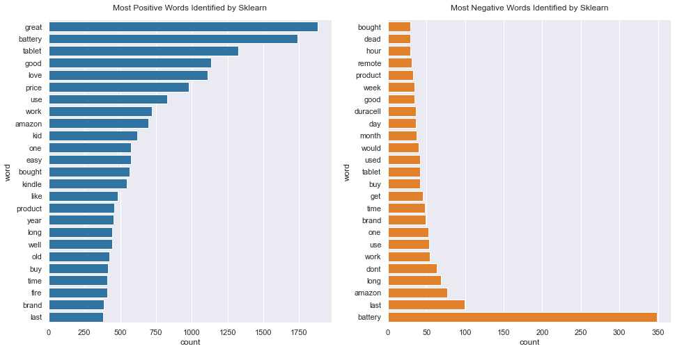

```python
sns.set_theme(style="darkgrid")
plt.figure(figsize=(16, 8))

plt.subplot(1, 2, 1)
sns.barplot(data=ml_posword_counts, y='word' , x='count', color='tab:blue')
plt.title("Most Positive Words Identified by Sklearn", y = 1.02)
sns.despine(left=True)

plt.subplot(1, 2, 2)
ax= sns.barplot(data=ml_negword_counts, y='word', x='count', color='tab:orange')
plt.title("Most Negative Words Identified by Sklearn", y = 1.02)
ax.invert_yaxis()

sns.despine(left=True)
plt.show()
```

### Positive and Negative words from Vader Sentiment Analysis

```python
vader_positive = df3[df3['vader_label'] == 1]
vader_negative = df3[df3['vader_label'] == 0]

# Count most frequent words
pos_list = []
for row in vader_positive['review_lems']:
    pos_list += row

vader_posword_counts = pd.Series(pos_list).value_counts()
vader_posword_counts= vader_posword_counts.to_frame().reset_index()
vader_posword_counts = vader_posword_counts.head(25).rename(columns={'index':'word', 0:'count'}) # Top 25

neg_list = []
for row in vader_negative['review_lems']:
    neg_list += row

vader_negword_counts = pd.Series(neg_list).value_counts()
vader_negword_counts= vader_negword_counts.to_frame().reset_index()
vader_negword_counts = vader_negword_counts.head(25).rename(columns={'index':'word', 0:'count'}) # Top 25
```

[figure not shown]

```python
sns.set_theme(style="darkgrid")
plt.figure(figsize=(16, 8))

plt.subplot(1, 2, 1)
sns.barplot(data=vader_posword_counts, y='word' , x='count', color='tab:blue')
plt.title("Most Positive Words Identified by Vader", y = 1.02)
sns.despine(left=True)

plt.subplot(1, 2, 2)
ax= sns.barplot(data=ml_negword_counts, y='word', x='count', color='tab:orange')
plt.title("Most vader_negword_counts Words Identified by Vader", y = 1.02)
ax.invert_yaxis()

sns.despine(left=True)
plt.show()
```

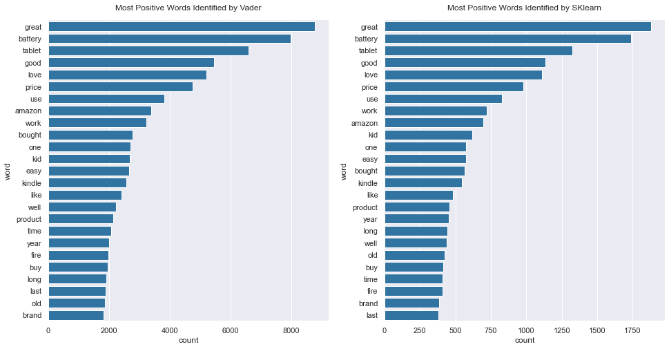

```python
sns.set_theme(style="darkgrid")
plt.figure(figsize=(16, 8))

plt.subplot(1, 2, 1)
sns.barplot(data=vader_posword_counts, y='word' , x='count', color='tab:blue')
plt.title("Most Positive Words Identified by Vader", y = 1.02)
sns.despine(left=True)

plt.subplot(1, 2, 2)
sns.barplot(data=ml_posword_counts, y='word', x='count', color='tab:blue')
plt.title("Most Positive Words Identified by SKlearn", y = 1.02)


sns.despine(left=True)
plt.show()
```

Because SKlearn requires us to split the dataset, the frequency count for words is lower. Other than that large difference, the two methods appear to identify roughly the same words as most positive.

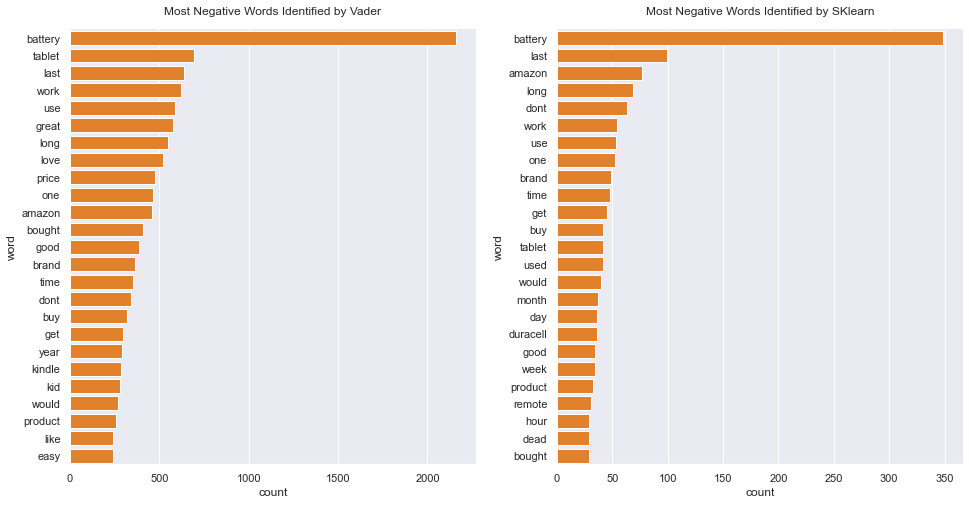

```python
sns.set_theme(style="darkgrid")
plt.figure(figsize=(16, 8))

plt.subplot(1, 2, 1)
sns.barplot(data=vader_negword_counts, y='word' , x='count', color='tab:orange')
plt.title("Most Negative Words Identified by Vader", y = 1.02)
sns.despine(left=True)

plt.subplot(1, 2, 2)
sns.barplot(data=ml_negword_counts, y='word', x='count', color='tab:orange')
plt.title("Most Negative Words Identified by SKlearn", y = 1.02)


sns.despine(left=True)
plt.show()
```

While the difference in word frequency remains, the difference in words is interesting. I'd say this is because Vader is better able to detect sentiment using word-order sensitive relationships.(https://github.com/cjhutto/vaderSentiment#introduction)

#### References

https://www.geeksforgeeks.org/python-sentiment-analysis-using-vader/ https://iaml.it/blog/optimizing-sklearn-pipelines  
https://www.tomasbeuzen.com/post/scikit-learn-gridsearch-pipelines/  
https://github.com/cjhutto/vaderSentiment#introduction  
https://towardsdatascience.com/cleaning-text-data-with-python-b69b47b97b76  
https://nlpforhackers.io/sentiment-analysis-intro/